# Exploring Carbon-Intensive Growth in the Indo-Pacific

- Show All Code
- Hide All Code
- View Source

DATA1001 Project 2 — Part 1 (Exploratory Data Analysis)

Author

Henry Ou

```r
library(tidyverse)
library(readr)
library(scales)

data_candidates <- c("../data/owid-co2-data.csv", "../Data/owid-co2-data.csv")
co2_path <- data_candidates[file.exists(data_candidates)][1]

if (is.na(co2_path)) {
  stop("Could not find owid-co2-data.csv in ../data or ../Data.")
}

co2_raw <- read_csv(co2_path, show_col_types = FALSE)

focus_countries <- c(
  "Australia", "Indonesia", "Vietnam", "India", "Philippines",
  "China", "Japan", "South Korea", "United States"
)

# Country-level panel with derived variables (OWID aggregates removed).
co2_countries <- co2_raw |>
  filter(!is.na(iso_code), !str_starts(iso_code, "OWID")) |>
  mutate(
    gdp_per_capita   = if_else(population > 0, gdp / population, NA_real_),
    carbon_intensity = if_else(gdp > 0, co2 / gdp, NA_real_),
    coal_share       = if_else(co2 > 0, coal_co2   / co2, NA_real_),
    oil_share        = if_else(co2 > 0, oil_co2    / co2, NA_real_),
    gas_share        = if_else(co2 > 0, gas_co2    / co2, NA_real_),
    cement_share     = if_else(co2 > 0, cement_co2 / co2, NA_real_)
  )

# Latest year with complete GDP / CO2 / population coverage.
latest_cs_year <- co2_countries |>
  filter(!is.na(gdp), !is.na(co2), !is.na(population)) |>
  summarise(y = max(year, na.rm = TRUE)) |>
  pull(y)
```

# Visualisations

Three figures, each looking at carbon-intensive growth through a different lens — income, time, and fuel mix.

**Fig 1 · Income**

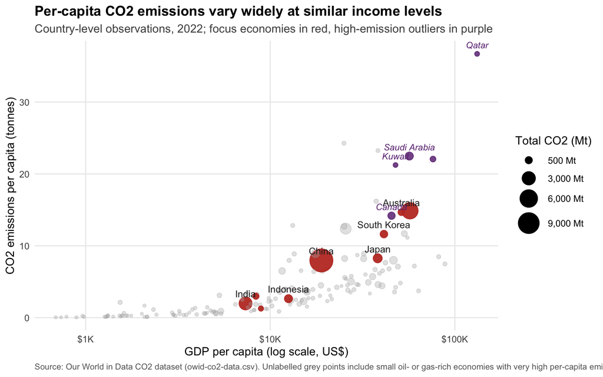

Figure 1: Per-capita CO2 emissions against GDP per capita in the latest complete year. Selected Indo-Pacific focus economies are shown in red; high-emission outliers (small oil- or gas-rich economies) are labelled in italic purple; all other countries are in light grey.

```r
# Additional outliers to label (oil / gas rich economies that otherwise
# appear as unlabelled grey points in the top of the chart).
outlier_countries <- c("Qatar", "United Arab Emirates", "Saudi Arabia",
                       "Kuwait", "Canada")

viz1_data <- co2_countries |>
  filter(year == latest_cs_year,
         !is.na(gdp_per_capita), !is.na(co2_per_capita), !is.na(co2)) |>
  mutate(
    label_group = case_when(
      country %in% focus_countries   ~ "focus",
      country %in% outlier_countries ~ "outlier",
      TRUE                           ~ "other"
    )
  )

ggplot(viz1_data, aes(x = gdp_per_capita, y = co2_per_capita)) +
  geom_point(aes(size = co2, colour = label_group, alpha = label_group)) +
  geom_text(data = filter(viz1_data, label_group == "focus"),
            aes(label = country),
            vjust = -0.9, size = 3.2, colour = "grey15",
            check_overlap = TRUE) +
  geom_text(data = filter(viz1_data, label_group == "outlier"),
            aes(label = country),
            vjust = -0.9, size = 3.0, colour = "#6c3483",
            fontface = "italic", check_overlap = TRUE) +
  scale_x_log10(labels = label_dollar(scale_cut = cut_short_scale())) +
  scale_size_continuous(
    range  = c(1, 10),
    breaks = c(500, 3000, 6000, 9000),
    labels = function(x) paste0(comma(x), " Mt"),
    name   = "Total CO2 (Mt)"
  ) +
  scale_colour_manual(
    values = c(focus = "#c0392b", outlier = "#6c3483", other = "grey70"),
    guide  = "none"
  ) +
  scale_alpha_manual(
    values = c(focus = 0.95, outlier = 0.85, other = 0.35),
    guide  = "none"
  ) +
  labs(
    title    = "Per-capita CO2 emissions vary widely at similar income levels",
    subtitle = paste0("Country-level observations, ", latest_cs_year,
                      "; focus economies in red, high-emission outliers in purple"),
    x        = "GDP per capita (log scale, US$)",
    y        = "CO2 emissions per capita (tonnes)",
    caption  = paste0(
      "Source: Our World in Data CO2 dataset (owid-co2-data.csv). ",
      "Unlabelled grey points include small oil- or gas-rich economies ",
      "with very high per-capita emissions."
    )
  ) +
  theme_minimal(base_size = 11) +
  theme(
    plot.title    = element_text(face = "bold"),
    plot.subtitle = element_text(colour = "grey30"),
    plot.caption  = element_text(colour = "grey40", size = 8, hjust = 0),
    panel.grid.minor = element_blank()
  )
```

**Fig 2 · Carbon intensity**

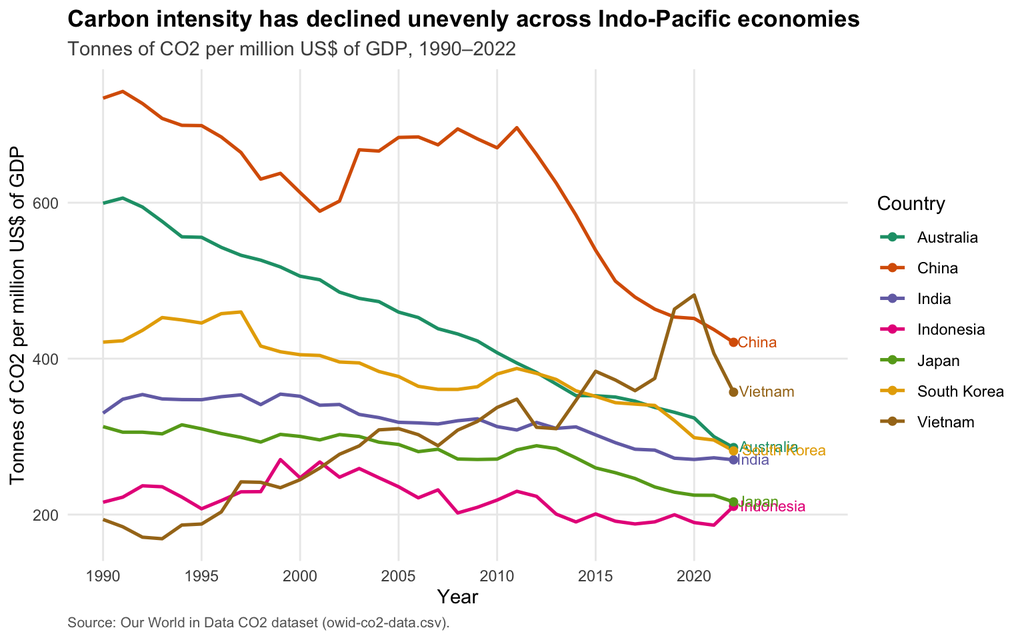

Figure 2: Carbon intensity (tonnes of CO2 per million US dollars of GDP) for seven Indo-Pacific economies, 1990 to the latest complete year. End-of-line country labels make the final positions easy to compare.

```r
trend_countries <- c("Australia", "China", "India", "Indonesia",
                     "Japan", "South Korea", "Vietnam")

# Convert CO2 (Mt) / GDP (USD) into tonnes per million US$ of GDP to avoid
# scientific notation on the axis.  Multiplier = 1e12.
viz2_data <- co2_countries |>
  filter(country %in% trend_countries,
         year >= 1990, year <= latest_cs_year,
         !is.na(carbon_intensity)) |>
  mutate(ci_t_per_musd = carbon_intensity * 1e12)

end_labels <- viz2_data |>
  group_by(country) |>
  filter(year == max(year)) |>
  ungroup()

ggplot(viz2_data, aes(x = year, y = ci_t_per_musd,
                      colour = country, group = country)) +
  geom_line(linewidth = 0.9) +
  geom_point(data = end_labels, size = 1.8) +
  geom_text(data = end_labels,
            aes(label = country),
            hjust = -0.1, vjust = 0.4, size = 3, show.legend = FALSE) +
  scale_colour_brewer(palette = "Dark2", name = "Country") +
  scale_x_continuous(breaks = seq(1990, latest_cs_year, 5),
                     limits = c(1990, latest_cs_year + 4)) +
  scale_y_continuous(labels = label_comma(accuracy = 1)) +
  labs(
    title    = "Carbon intensity has declined unevenly across Indo-Pacific economies",
    subtitle = paste0("Tonnes of CO2 per million US$ of GDP, 1990\u2013",
                      latest_cs_year),
    x        = "Year",
    y        = "Tonnes of CO2 per million US$ of GDP",
    caption  = "Source: Our World in Data CO2 dataset (owid-co2-data.csv)."
  ) +
  theme_minimal(base_size = 11) +
  theme(
    plot.title       = element_text(face = "bold"),
    plot.subtitle    = element_text(colour = "grey30"),
    plot.caption     = element_text(colour = "grey40", size = 8, hjust = 0),
    panel.grid.minor = element_blank(),
    legend.position  = "right"
  )
```

**Fig 3 · Fuel mix**

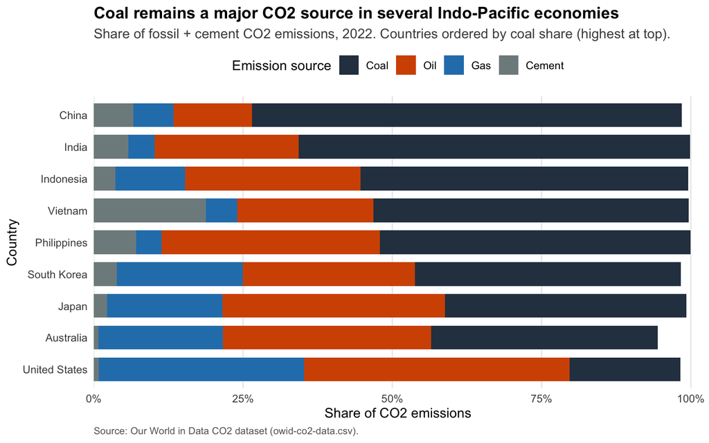

Figure 3: Share of coal, oil, gas and cement in total fossil + cement CO2 emissions for the nine focus economies in the latest complete year. Countries are ordered so that the highest coal share appears at the top.

```r
viz3_wide <- co2_countries |>
  filter(country %in% focus_countries, year == latest_cs_year) |>
  transmute(country,
            Coal   = coal_share,
            Oil    = oil_share,
            Gas    = gas_share,
            Cement = cement_share)

# Order countries so the country with the highest coal share appears at the top.
country_order <- viz3_wide |>
  arrange(Coal) |>           # ascending -> after coord_flip, highest at top
  pull(country)

viz3_data <- viz3_wide |>
  pivot_longer(-country, names_to = "source", values_to = "share") |>
  filter(!is.na(share)) |>
  mutate(
    source  = factor(source, levels = c("Coal", "Oil", "Gas", "Cement")),
    country = factor(country, levels = country_order)
  )

ggplot(viz3_data, aes(x = country, y = share, fill = source)) +
  geom_col(width = 0.75) +
  coord_flip() +
  scale_y_continuous(labels = label_percent(accuracy = 1),
                     expand = expansion(mult = c(0, 0.02))) +
  scale_fill_manual(
    values = c(Coal   = "#2c3e50",
               Oil    = "#d35400",
               Gas    = "#2980b9",
               Cement = "#7f8c8d"),
    breaks = c("Coal", "Oil", "Gas", "Cement"),
    labels = c("Coal", "Oil", "Gas", "Cement"),
    name   = "Emission source"
  ) +
  labs(
    title    = "Coal remains a major CO2 source in several Indo-Pacific economies",
    subtitle = paste0("Share of fossil + cement CO2 emissions, ", latest_cs_year,
                      ". Countries ordered by coal share (highest at top)."),
    x        = "Country",
    y        = "Share of CO2 emissions",
    caption  = "Source: Our World in Data CO2 dataset (owid-co2-data.csv)."
  ) +
  theme_minimal(base_size = 11) +
  theme(
    plot.title         = element_text(face = "bold"),
    plot.subtitle      = element_text(colour = "grey30"),
    plot.caption       = element_text(colour = "grey40", size = 8, hjust = 0),
    panel.grid.major.y = element_blank(),
    panel.grid.minor   = element_blank(),
    legend.position    = "top"
  )
```

# Discussion

**Data and framing.** This analysis uses the [*Our World in Data* CO2 and Greenhouse Gas Emissions dataset](https://ourworldindata.org/co2-and-greenhouse-gas-emissions) (`owid-co2-data.csv`), filtered to country-level observations so that regional and income-group `OWID_*` aggregates are excluded. Cross-sectional figures use 2022, the most recent year with complete GDP coverage for the focus economies. The exploratory question is: *which Indo-Pacific economies show patterns of high carbon intensity, rising emissions, or fossil-fuel dependence that may justify closer analysis in a future client report?*

**Link to future report.** Taken together, these figures suggest that future analysis should consider emissions scale alongside economic context, carbon-intensity trends and fuel composition. The later report can therefore carry forward three indicators: emissions relative to economic context, the trajectory of carbon intensity, and the share of coal in total emissions. No final recommendation is made at this stage; the plots identify the countries and indicators that warrant more formal investigation.

# Acknowledgements

- **Dataset:** [*Our World in Data* CO2 and Greenhouse Gas Emissions dataset](https://ourworldindata.org/co2-and-greenhouse-gas-emissions), file `owid-co2-data.csv`, compiled from the Global Carbon Project, the Energy Institute Statistical Review of World Energy, the Carbon Dioxide Information Analysis Center, and the World Bank.
- **R packages:** `tidyverse`, `readr`, `scales` (which load `ggplot2`, `dplyr`, `tidyr`, `stringr`).
- **Course materials:** DATA1001 Project 2 brief and EDA template provided in Canvas.

## AI Usage

[output not shown]